# math250_nov5_Soupafied

Author

Josmar Osorio

## Inference Problems

```r
library(tidyverse)
library(ISLR2)
```

We will be using the `Carseats` dataset from the `ISLR2` package for the following problems.

```r
glimpse(Carseats)
```

```
Rows: 400
Columns: 11
$ Sales       <dbl> 9.50, 11.22, 10.06, 7.40, 4.15, 10.81, 6.63, 11.85, 6.54, …
$ CompPrice   <dbl> 138, 111, 113, 117, 141, 124, 115, 136, 132, 132, 121, 117…
$ Income      <dbl> 73, 48, 35, 100, 64, 113, 105, 81, 110, 113, 78, 94, 35, 2…
$ Advertising <dbl> 11, 16, 10, 4, 3, 13, 0, 15, 0, 0, 9, 4, 2, 11, 11, 5, 0, …
$ Population  <dbl> 276, 260, 269, 466, 340, 501, 45, 425, 108, 131, 150, 503,…
$ Price       <dbl> 120, 83, 80, 97, 128, 72, 108, 120, 124, 124, 100, 94, 136…
$ ShelveLoc   <fct> Bad, Good, Medium, Medium, Bad, Bad, Medium, Good, Medium,…
$ Age         <dbl> 42, 65, 59, 55, 38, 78, 71, 67, 76, 76, 26, 50, 62, 53, 52…
$ Education   <dbl> 17, 10, 12, 14, 13, 16, 15, 10, 10, 17, 10, 13, 18, 18, 18…
$ Urban       <fct> Yes, Yes, Yes, Yes, Yes, No, Yes, Yes, No, No, No, Yes, Ye…
$ US          <fct> Yes, Yes, Yes, Yes, No, Yes, No, Yes, No, Yes, Yes, Yes, N…
```

## Problem 1

The company claims that the average price of their Carseats is 110. We will test this claim.

**Null Hypothesis**: ($\mu = 110$)

**Alternative hypothesis**: ($\mu \ne 110$)

```r
t.test(Carseats$Price,
       mu = 110)
```

```
    One Sample t-test

data:  Carseats$Price
t = 4.8951, df = 399, p-value = 1.429e-06
alternative hypothesis: true mean is not equal to 110
95 percent confidence interval:
 113.4677 118.1223
sample estimates:
mean of x
  115.795
```

With a `p-value` of 1.429e-06 we overwhelmingly reject the null hypothesis. This means we reject the claim that the true mean price of the carseats is 110, and that the company is wrong.

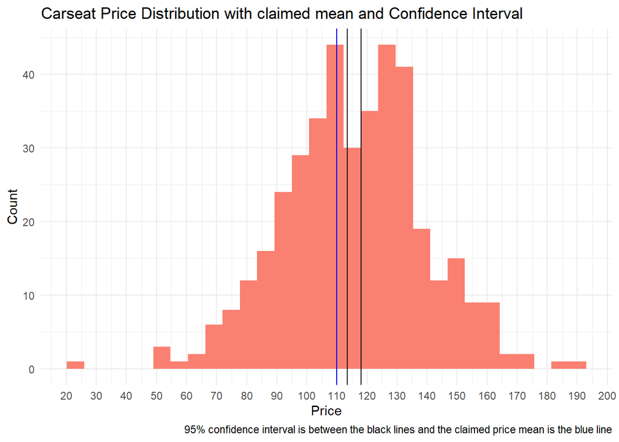

```r
ggplot(Carseats, aes(x = Price)) +
  geom_histogram(fill = "salmon") +
  geom_vline(xintercept = 113.4677) +
  geom_vline(xintercept = 118.1223) +
  geom_vline(xintercept = 110, color = "blue") +
  scale_x_continuous(breaks = seq(0, 200, by = 10)) +
  theme_minimal()+
  labs(
    title = "Carseat Price Distribution with claimed mean and Confidence Interval",
    caption = "95% confidence interval is between the black lines and the claimed price mean is the blue line",
    y = "Count"

  )
```

From the plot it is clear that 110 is not between where we think the true mean is. We cannot accept the claim that the average price is 110.

## Problem 2

We will now compute a 90% confidence interval for the mean competitor price in the population.

```r
t.test(Carseats$CompPrice, conf.level = 0.90)
```

```
    One Sample t-test

data:  Carseats$CompPrice
t = 163, df = 399, p-value < 2.2e-16
alternative hypothesis: true mean is not equal to 0
90 percent confidence interval:
 123.7109 126.2391
sample estimates:
mean of x
  124.975
```

```r
compPrice_m <- mean(Carseats$CompPrice)
compPrice_m
```

```
[1] 124.975
```

**Sample Mean**:

$\bar{x} = 124.975$

```r
MOE <- (126.2391-123.7109)/2
MOE
```

```
[1] 1.2641
```

**Margin Of Error**:

$ME = \pm 1.2641$

**Confidence Interval**:

$CI = 124.975 \pm 1.2641$

## Problem 3

For this problem we will be using the `penguins` data set to create a contingency table of the `species`, `island` and marginal counts.

```r
t <- table(penguins$species,penguins$island)

addmargins(t)
```

```
            Biscoe Dream Torgersen Sum
  Adelie        44    56        52 152
  Chinstrap      0    68         0  68
  Gentoo       124     0         0 124
  Sum          168   124        52 344
```

## Problem 4

Upload to Github